# Project_Assignment

Nishant Sinha

Tuesday, January 20, 2015

The prediction problem was processed through a series of 5 steps. The steps were:  
1) Reading the data  
2) Preprocessing data  
3) Training the Model  
4) Generating the Model statistics  
5) Predicting the outcome of test cases using the finalized model.  
The project relied on data patterns and statistical test outcomes to finalize the data model. The variable selection process has been primarly driven by variance checks, correlation checks and number of unique values presence. The project doesnt use any Data Dictionary (which could have been used for effectively shortlisting the variables and making model more explainable) or expanded train grid for cross validation (due to limitations in computation powers at the users end. The iterations on trimmed down dataset using parallel processing (3 cores) requried 9 hours for running 1000 iterations,with shrinkage of .1 and cross valdiation repeat of 10).

The next few sections will talk about details at each of the above 5 step along with associated R code.

**Step 1: Reading the data**

```r
library(RCurl)
library(caret)
```

```r
# Importing data for Training Dataset
URL <- "https://d396qusza40orc.cloudfront.net/predmachlearn/pml-training.csv"
projdata.training <- read.csv(textConnection(getURL(URL,ssl.verifypeer = FALSE)))

# Importing data for Testing Dataset
URL1 <- "https://d396qusza40orc.cloudfront.net/predmachlearn/pml-testing.csv"
projdata.testing <- read.csv(textConnection(getURL(URL1,ssl.verifypeer = FALSE)))

# Profiling Training data on dependant variable
table(projdata.training$classe)
```

```
##
##    A    B    C    D    E
## 5580 3797 3422 3216 3607
```

```r
ncol(projdata.training)
```

```
## [1] 160
```

**Step 2: Preprocessing the data**

```r
# Removing variables that are timestamps or userids
preprocess0<-subset(projdata.training,select=-c(user_name))
preprocess0 <- preprocess0[grep("timestamp", names(preprocess0), value = TRUE, invert = TRUE)]
ncol(preprocess0)
```

```
## [1] 156
```

The number of variables are reduced from 160 to 156, as 4 variables on usernames and time stamps are removed. These variables are identifiers and would add noise to the predictive model.

```r
# variables with large number of unique values
preprocess1 <- nearZeroVar(preprocess0, saveMetrics= TRUE)
head(preprocess1)
```

```
##            freqRatio percentUnique zeroVar   nzv
## X           1.000000  100.00000000   FALSE FALSE
## new_window 47.330049    0.01019264   FALSE  TRUE
## num_window  1.000000    4.37264295   FALSE FALSE
## roll_belt   1.101904    6.77810621   FALSE FALSE
## pitch_belt  1.036082    9.37722964   FALSE FALSE
## yaw_belt    1.058480    9.97349913   FALSE FALSE
```

```r
colnames(preprocess1)
```

```
## [1] "freqRatio"     "percentUnique" "zeroVar"       "nzv"
```

```r
# Removing variables with nzv = TRUE
preprocess2 <- preprocess1[preprocess1$nzv == FALSE,]
summary(preprocess2)
```

```
##    freqRatio      percentUnique        zeroVar           nzv
##  Min.   : 1.000   Min.   :  0.02548   Mode :logical   Mode :logical
##  1st Qu.: 1.037   1st Qu.:  0.85491   FALSE:96        FALSE:96
##  Median : 1.127   Median :  1.95444   NA's :0         NA's :0
##  Mean   : 5.247   Mean   :  6.49664
##  3rd Qu.: 1.818   3rd Qu.:  4.03883
##  Max.   :87.256   Max.   :100.00000
```

The number of variables reduce to 96 after removing variables with variance near to zero.

```r
#Removing variables that have greater than 80% numeric values as unique
preprocess3 <- preprocess2[preprocess2$percentUnique < 80,]
summary(preprocess3)
```

```
##    freqRatio      percentUnique       zeroVar           nzv
##  Min.   : 1.000   Min.   : 0.02548   Mode :logical   Mode :logical
##  1st Qu.: 1.037   1st Qu.: 0.82433   FALSE:92        FALSE:92
##  Median : 1.127   Median : 1.86525   NA's :0         NA's :0
##  Mean   : 5.416   Mean   : 2.98090
##  3rd Qu.: 1.818   3rd Qu.: 3.52793
##  Max.   :87.256   Max.   :15.73234
```

The number of variables reduce to 92 after removing variables with greater than 80% as unique values. These are typically the tail end of high variance variables.

```r
#Removing variables that have skewed distribution
preprocess4 <- preprocess3[preprocess3$freqRatio < 50,]
summary(preprocess4)
```

```
##    freqRatio      percentUnique       zeroVar           nzv
##  Min.   : 1.000   Min.   : 0.02548   Mode :logical   Mode :logical
##  1st Qu.: 1.037   1st Qu.: 0.78993   FALSE:89        FALSE:89
##  Median : 1.123   Median : 1.72765   NA's :0         NA's :0
##  Mean   : 3.289   Mean   : 2.58572
##  3rd Qu.: 1.615   3rd Qu.: 2.95587
##  Max.   :33.029   Max.   :14.65702
```

The number of variables reduce to 89 (including the dependant “classe” variable) for correlation checks.

```r
# Keeping the variables selected from above preprocessing
varlist<-rownames(preprocess4)
projdata.training.preprocess <- projdata.training[varlist]
ncol(projdata.training.preprocess)
```

```
## [1] 89
```

```r
# Finding out any correlated data
descrCor <-  cor(projdata.training.preprocess[,1:88], use="pairwise.complete.obs")
highCorr <- sum(abs(descrCor[upper.tri(descrCor)]) > .999)
highCorr
```

```
## [1] 0
```

**Step 3 - Training the Model**

```r
# Training the model using gradient boosting method and default control parameters i.e. validation is bootstrap number of resampling iterations = 25 , p=.75
set.seed=1234567
modelfit.gbm <- train(x=trainX,y=trainY,method="gbm",verbose=FALSE)
modelfit.gbm$finalModel
```

```
## A gradient boosted model with multinomial loss function.
## 150 iterations were performed.
## There were 88 predictors of which 39 had non-zero influence.
```

The model has been fitted on default parameters as making changes to the contorl parameters or train grid was tending to make the model execution quite long. The model was trained on Boot strap validation with resampling iteration of around 25 and samplign probability of .75.

**Step 4 - Generating the Model statistics**

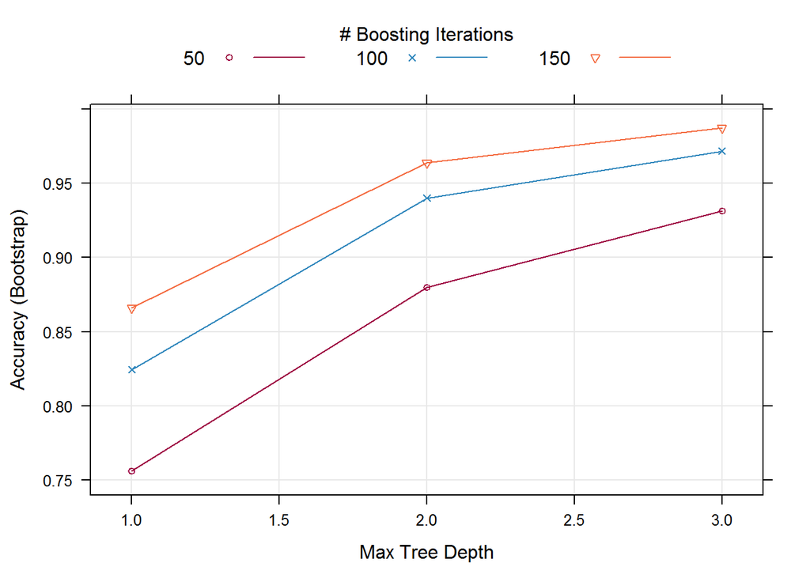

```r
trellis.par.set(caretTheme())
plot(modelfit.gbm)
```

```r
varImp(modelfit.gbm$finalModel)
```

```
##                              Overall
## num_window               3973.768833
## roll_belt                3727.793073
## pitch_belt                404.156003
## yaw_belt                 1151.192747
## total_accel_belt            0.000000
## max_roll_belt               0.000000
## max_picth_belt              0.000000
## min_roll_belt               0.000000
## min_pitch_belt              0.000000
## amplitude_roll_belt         0.000000
## amplitude_pitch_belt        0.000000
## var_total_accel_belt        0.000000
## avg_roll_belt               0.000000
## stddev_roll_belt            0.000000
## var_roll_belt               0.000000
## avg_pitch_belt              0.000000
## stddev_pitch_belt           0.000000
## var_pitch_belt              0.000000
## avg_yaw_belt                0.000000
## stddev_yaw_belt             0.000000
## var_yaw_belt                0.000000
## gyros_belt_x                0.000000
## gyros_belt_y               79.928565
## gyros_belt_z              354.074992
## accel_belt_x                0.000000
## accel_belt_y                0.000000
## accel_belt_z                8.041817
## magnet_belt_x             156.024016
## magnet_belt_y             151.322826
## magnet_belt_z             591.234482
## yaw_arm                   347.618048
## total_accel_arm             0.000000
## var_accel_arm               0.000000
## gyros_arm_x                15.763631
## gyros_arm_y                81.373296
## gyros_arm_z                 0.000000
## accel_arm_x               104.056231
## accel_arm_y                 7.217055
## accel_arm_z                 8.211336
```

[output cut: 34 more lines]

```
## yaw_forearm                34.453214
## max_picth_forearm           0.000000
## min_pitch_forearm           0.000000
## amplitude_pitch_forearm     0.000000
## total_accel_forearm        12.939775
## var_accel_forearm           0.000000
## gyros_forearm_x             0.000000
## gyros_forearm_y             0.000000
## gyros_forearm_z            13.375122
## accel_forearm_x           717.137667
## accel_forearm_y            16.559312
## accel_forearm_z           137.820941
## magnet_forearm_x          222.153877
## magnet_forearm_y           44.158577
## magnet_forearm_z          406.342932
```

```r
gbm.pred <- predict(modelfit.gbm, trainX)
confusionMatrix(gbm.pred,trainY)
```

```
## Confusion Matrix and Statistics
##
##           Reference
## Prediction    A    B    C    D    E
##          A 5570   22    0    0    0
##          B    8 3754   11   10    6
##          C    0   19 3406   24    2
##          D    1    2    4 3179   12
##          E    1    0    1    3 3587
##
## Overall Statistics
##
##                Accuracy : 0.9936
##                  95% CI : (0.9924, 0.9946)
##     No Information Rate : 0.2844
##     P-Value [Acc > NIR] : < 2.2e-16
##
##                   Kappa : 0.9919
##  Mcnemar's Test P-Value : NA
##
## Statistics by Class:
##
##                      Class: A Class: B Class: C Class: D Class: E
## Sensitivity            0.9982   0.9887   0.9953   0.9885   0.9945
## Specificity            0.9984   0.9978   0.9972   0.9988   0.9997
## Pos Pred Value         0.9961   0.9908   0.9870   0.9941   0.9986
## Neg Pred Value         0.9993   0.9973   0.9990   0.9977   0.9988
## Prevalence             0.2844   0.1935   0.1744   0.1639   0.1838
## Detection Rate         0.2839   0.1913   0.1736   0.1620   0.1828
## Detection Prevalence   0.2850   0.1931   0.1759   0.1630   0.1831
## Balanced Accuracy      0.9983   0.9932   0.9963   0.9937   0.9971
```

```r
projdata.testing.preprocess <- projdata.testing[varlist[1:88]]
str(projdata.testing.preprocess)
```

```
## 'data.frame':    20 obs. of  88 variables:
##  $ num_window              : int  74 431 439 194 235 504 485 440 323 664 ...
##  $ roll_belt               : num  123 1.02 0.87 125 1.35 -5.92 1.2 0.43 0.93 114 ...
##  $ pitch_belt              : num  27 4.87 1.82 -41.6 3.33 1.59 4.44 4.15 6.72 22.4 ...
##  $ yaw_belt                : num  -4.75 -88.9 -88.5 162 -88.6 -87.7 -87.3 -88.5 -93.7 -13.1 ...
##  $ total_accel_belt        : int  20 4 5 17 3 4 4 4 4 18 ...
##  $ max_roll_belt           : logi  NA NA NA NA NA NA ...
##  $ max_picth_belt          : logi  NA NA NA NA NA NA ...
##  $ min_roll_belt           : logi  NA NA NA NA NA NA ...
##  $ min_pitch_belt          : logi  NA NA NA NA NA NA ...
##  $ amplitude_roll_belt     : logi  NA NA NA NA NA NA ...
##  $ amplitude_pitch_belt    : logi  NA NA NA NA NA NA ...
##  $ var_total_accel_belt    : logi  NA NA NA NA NA NA ...
##  $ avg_roll_belt           : logi  NA NA NA NA NA NA ...
##  $ stddev_roll_belt        : logi  NA NA NA NA NA NA ...
```

[output cut: 74 more lines]

```r
projdata.testing.preprocess[is.na(projdata.testing.preprocess)] <- 0
gbm.test.pred <- predict(modelfit.gbm,projdata.testing.preprocess)
gbm.test.pred
```

```
##  [1] B A B A A E D B A A B C B A E E A B B B
## Levels: A B C D E
```